# probandoParaTP

2025-10-14

## TP Econometría

Consigna:

1. Realizar un análisis estadístico de las variables bajo estudio en forma individual y de manera bivariada. Puntualmente: Calcular medidas de posición, de variabilidad, características superiores y realizar gráficos que presenten las series y muestren su grado de vinculación con las demás variables.
2. Presentar el modelo a estimar. Comentar sus características salientes y explicar la razonabilidad de la magnitud y signo esperado de los coeficientes de regresión a obtenerse.
3. Realizar una salida de regresión y comentar los resultados y de los indicadores estadísticos obtenidos, juzgando su razonabilidad.
4. Especificar e interpretar el Coeficiente de Determinación Múltiple.
5. Estimar Intervalos de Confianza y Test de Hipótesis para los coeficientes de regresión, suponiendo un margen de error del 5%.
6. Realizar una predicción puntual y otra por intervalos y asumir un margen de error del 5%.
7. Comprobar la presencia de multicolinealidad en caso de corresponder.
8. Reexpresar el modelo en logaritmos. Estimar el modelo en su versión logarítmica tomando con tal finalidad la variable dependiente como logaritmo y una (o dos) variables explicativas a elección en logaritmos. Concluir sobre la interpretación de los coeficientes estimados y sobre la incidencia de dicha transformación sobre las pruebas de validación y de bondad de ajuste.
9. Verificar si existe un error de especificación.
10. Testear por heterocedasticidad.

### CEOSAL

```r
library(wooldridge)
data(ceosal1, package='wooldridge')

head(ceosal1)
```

```
##   salary pcsalary   sales  roe pcroe ros indus finance consprod utility
## 1   1095       20 27595.0 14.1 106.4 191     1       0        0       0
## 2   1001       32  9958.0 10.9 -30.6  13     1       0        0       0
## 3   1122        9  6125.9 23.5 -16.3  14     1       0        0       0
## 4    578       -9 16246.0  5.9 -25.7 -21     1       0        0       0
## 5   1368        7 21783.2 13.8  -3.0  56     1       0        0       0
## 6   1145        5  6021.4 20.0   1.0  55     1       0        0       0
##    lsalary    lsales
## 1 6.998509 10.225389
## 2 6.908755  9.206132
## 3 7.022868  8.720281
## 4 6.359574  9.695602
## 5 7.221105  9.988894
## 6 7.043160  8.703075
```

#### 1. Analisis de variables

Qué cosas puedo analizar de las variables? - distribución de cada una (media, var, grafico de distribución/hist) - relación con la variable objetivo (salary) (grafico bivariado)(covar con salary?) - matriz de correlación entre las posibles variables predictoras (evitamos multicolinealidad)

```r
medias <- c()
vars <- c()
i <- 1
for (columna in colnames(ceosal1)){
  medias <- c(medias, mean(ceosal1[[columna]]))
  vars <- c(vars, var(ceosal1[[columna]]))
}
medias
```

```
##  [1] 1281.1196172   13.2822967 6923.7932823   17.1842105   10.8004784
##  [6]   61.8038278    0.3205742    0.2200957    0.2870813    0.1722488
## [11]    6.9503861    8.2922648
```

```r
vars
```

```
##  [1] 1.883332e+06 1.064973e+03 1.130665e+08 7.256499e+01 9.451612e+03
##  [6] 4.648110e+03 2.188535e-01 1.724788e-01 2.056496e-01 1.432646e-01
## [11] 3.207796e-01 1.026494e+00
```

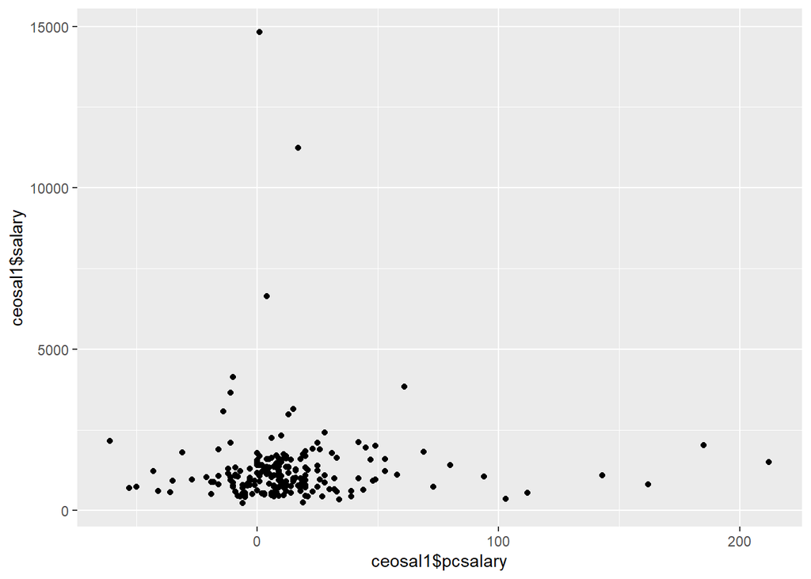

```r
ggplot(data = ceosal1)+
  geom_point(aes(x=ceosal1$pcsalary, y=ceosal1$salary))
```

```r
data(ceosal1, package='wooldridge')
data(audit, package='wooldridge')
data(wage1, package='wooldridge')
data(vote1, package='wooldridge')
data(meap93, package='wooldridge')
data(gpa1, package='wooldridge')
data(crime1, package='wooldridge')
data(discrim, package='wooldridge')
data(hprice2, package='wooldridge')
```